# Supplementary appendix to “Assessing real-world vaccine effectiveness from routine surveillance data in Switzerland”

Report generated on Date: 2021-12-03 Time: 18:33

# Methods

## Definition of vaccination status

Information about the vaccination status are part of the clinical reporting form, so that vaccination status will remain unknown if this form was not filled. The clinical reporting form is only mandatory in case of hospitalization or death. Individuals are considered fully vaccinated if they received either two doses of Moderna or Pfizer-BioNtech vaccine, one dose of Johnson-Johnson vaccine, or one dose of Moderna or Pfizer-BioNtech vaccine with a previous positive test. Individuals are considered partially vaccinated if they received just one dose of Moderna or Pfizer-BioNtech without a previous positive test. Individuals are considered non-vaccinated if they reported having not received any dose.

## Model structure

We use a model to estimate vaccine effectiveness against hospitalization or death from routine surveillance data, accounting for the varying dynamics of vaccination coverage by age and canton. We present the model using hospitalizations and vaccine effectiveness against hospitalization as an example, but the same applies to deaths.

Consider only all reported COVID-19 hospitalizations $H$, that can be either fully vaccinated ($V$) or not fully vaccinated ($\bar{V}$). We define the relative risk of hospitalization without full vaccination compared to with full vaccination

$$RR = \frac{\Pr(H | \bar{V})}{\Pr(H | V)}$$
where $\Pr(H | V)$ and $\Pr(H | \bar{V})$ refer to the probability of becoming hospitalized despite full vaccination or without full vaccination, respectively. The relative risk of hospitalization without full vaccination compared to with full vaccination translates into a relative risk reduction of hospitalization through:
$$RRR = 1-\frac{1}{RR}$$
Now consider the observed proportion of fully vaccinated among hospitalizations, $\Pr(V | H)$. If the vaccine has no effect at all, that is if $RR = 1$, we expect it to be the same as the proportion of fully vaccinated in the general population at this time and place

$$\Pr(V | H) = \Pr(V).$$
If, however, the vaccine helps preventing hospitalizations, this equality will not hold. Bayes rule tells us that

$$\Pr(V|H) = \frac{\Pr(H | V) \Pr(V)}{\Pr(H)}.$$
We can apply the law of total probability to the denominator

$$\Pr(V | H) = \frac{\Pr(H | V) \Pr(V)}{\Pr(H | V) \Pr(V) + \Pr(H | \bar{V}) \Pr(\bar{V})}$$
and then, using equation 1, replace $\Pr(H | \bar{V})$ by $RR \times \Pr(H | V)$
$$\Pr(V | H) = \frac{\Pr(H | V) \Pr(V)}{\Pr(H | V) \Pr(V) + RR \times \Pr(H | V) \Pr(\bar{V})}$$
and simplify to finally obtain
$$\Pr(V | H) = \frac{\Pr(V)}{\Pr(V) + RR (1-\Pr(V))}.$$
We rely upon the assumption that the vaccination status was captured without bias among hospitalized.

## Estimation

If we have data about the proportion of fully vaccinated in the population and about the proportion of fully vaccinated among hospitalized COVID-19 cases, then it becomes possible to estimate vaccine effectiveness against hospitalization.

For that we use a likelihood-based approach. Let $y_i$ be the vaccination status of case $i$ (1 is fully vaccinated, 0 is not fully vaccinated). We also need the information about the vaccine coverage corresponding to case $i$. at the time that case $i$ was reported $t_i$. We know that in Switzerland, the vaccination campaigns were cantonal and prioritized vulnerable populations (that can be approximated by age). As a result, vaccination coverage progressed differently in different age groups, and progressed at different rates in different cantons.

Therefore we consider $v_i$, the vaccination coverage at time $t_i$ in the population of the same canton and age group as case $i$. We can then write the following likelihood:
$$\Pr(y_i | RR) = \text{Bernoulli}(p_i)$$
where $p_i$ is the expected probability that case $i$ is fully vaccinated
$$p_i = \frac{v_i}{v_i + RR (1-v_i)}.$$
We can then estimate $\widehat{RR}$ by optimizing
$$\mathcal{L}(y, RR) = \prod_i \text{Bernoulli}(p_i).$$
Note that $RR$ is strictly positive. We consider $\widehat{RR}$ as an estimator of the relative risk of hospitalization without full vaccination compared to with full vaccination, adjusted for the dynamics of vaccine coverage by canton and age group.

## Covariates

We may consider that vaccine effectiveness against vaccination can vary according to individual characteristics, unrelated to the dynamics of vaccine coverage. Following the principles of general linear models, we extend the model to allow for such variation and consider $RR$ as a linear combination (on the log scale) of
$$RR = \exp(\alpha + X \beta )$$
where $\alpha$ is an intercept, $\beta$ is a vector of coefficients and $X$ is a matrix of covariates. The exponential function ensures that $RR$ remains positive. With this formulation, we can study the variation of vaccine effectiveness by age group or time since vaccination. If there is only 1 covariate, this approach will lead to the same results as stratification by levels of the covariate.

## Relative change in RR by vaccine type

The present model also applies to relative effectiveness between Moderna and Pfizer-BioNtech. In that case, the analysis is limited to fully vaccinated only, and the comparison is on the proportion of each type of vaccine among fully vaccinated hospitalizations. The equations above hold if we replace $V$ and $\bar{V}$ (meaning fully vaccinated or not fully vaccinated) by $V_M$ and $V_P$ (meaning vaccinated with Moderna or vaccinated with Pfizer-BioNtech). In this situation of course, we only conclude on the relative effectiveness of one type of vaccine compared to another, without any consideration for the overall effectiveness that can be high for both.

## Relative change in RR by time since vaccination

The previous approach can be extended to assess the change in the $RR$ of hospitalization by time since vaccination. In that case, the analysis is limited to fully vaccinated only, and the comparison is on the proportion of hospitalized people that have been vaccinated for 0 to 12 weeks ($V_1$), for 13 to 24 weeks ($V_2$) or for 25 weeks or more ($V_3$). In this case we use three equations:

$$\Pr(V_1 | H) = \frac{\Pr(V_1)}{\Pr(V_1) + \gamma_2 \Pr(V_2) + \gamma_3 \Pr(V_3)}$$
for the expected proportion of $V_1$,

$$\Pr(V_2 | H) = \frac{\Pr(V_2)}{1/\gamma_2\Pr(V_1) + \Pr(V_2) + \gamma_3/\gamma_2 \Pr(V_3)}$$
for the expected proportion of $V_2$, and
$$\Pr(V_3 | H) = 1- \Pr(V_1 | H) - \Pr(V_2 | H)$$
for the expected proportion of $V_3$. We can then estimate $\gamma_2$ and $\gamma_3$ by maximizing a categorical likelihood. The values of $\gamma_2$ and $\gamma_3$ can then be interpreted as the relative change in the $RR$ of hospitalization for individuals of group $V_2$ and $V_3$, respectively, compared to the reference group $V_1$.

# Additional results

## Missing vaccination status

There was high missing of vaccination status early 2021, which gradually decreased down to around 10-15% in the last few months (Figure S1). This was due to the fact that the clinical notification form was adapted to collect information about vaccination status in early 2021, but this new version was not immediately adopted by all health professionals.

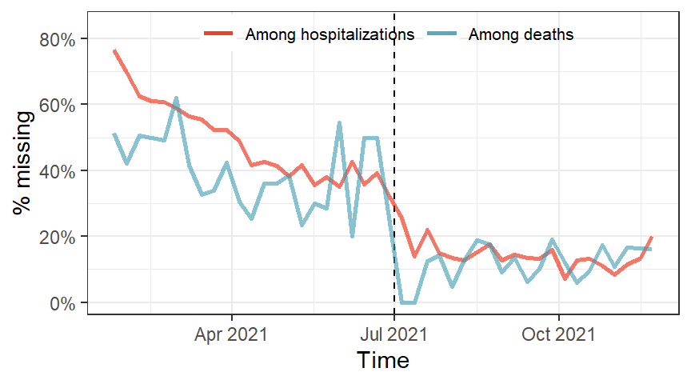

**Figure S1.** Proportion of hospitalizations and deaths with missing information about the vaccination status. The dashed vertical lien corresponds to the starting date of our analyses.

## Vaccine types

Early vaccination campaigns in Switzerland used about equally Moderna or Pfizer-BioNtech, but Moderna was used more often from June 2021 onwards. Johnson-Johnson started being used in October 2021.

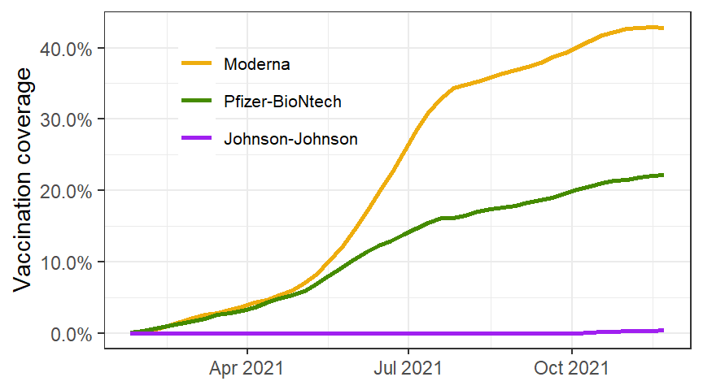

**Figure S2.** Vaccine coverage in Switzerland over time by type of vaccine (Moderna, Pfizer-BioNtech and Johnson-Johnson).

## Vaccine effectiveness against hospitalization and death

These tables show the estimates of $RR$ of hospitalization or death without full vaccination compared to full vaccination used to produce Figure 2 in the main article. We also show the corresponding values of the relative risk reduction against hospitalization or death (1-1/$RR$), that can be interpreted as estimates of vaccine effectiveness.

**Table S1.** Relative risk of hospitalization (and 95% confidence intervals) for non-fully vaccinated compared to fully vaccinated, with the corresponding estimations of vaccine effectiveness against hospitalization.

| Stratification |  | Relative risk of hospitalization | Vaccine effectiveness against hospitalization |
| --- | --- | --- | --- |
| None | Baseline | 12.5 (11.7-13.4) | 92.0% (91.4-92.5%) |
|  | Multiple imputation | 12.5 (11.7-13.4) | 92.0% (91.4-92.5%) |
|  | Best case scenario | 15.7 (14.7-16.8) | 93.6% (93.2-94.1%) |
|  | Worst case scenario | 6.6 (6.2-7.0) | 84.9% (84.0-85.7%) |
| Age group | 0-39 | 16.9 (12.4-23.0) | 94.1% (92.0-95.7%) |
|  | 40-49 | 25.4 (18.8-34.4) | 96.1% (94.7-97.1%) |
|  | 50-59 | 23.5 (18.8-29.3) | 95.7% (94.7-96.6%) |
|  | 60-69 | 19.0 (15.9-22.7) | 94.7% (93.7-95.6%) |
|  | 70-79 | 9.3 (8.1-10.6) | 89.2% (87.6-90.6%) |
|  | 80+ | 7.8 (6.9-8.9) | 87.2% (85.5-88.7%) |
| Month | July 2021 | 17.4 (11.9-25.4) | 94.2% (91.6-96.1%) |
|  | August 2021 | 19.2 (16.4-22.4) | 94.8% (93.9-95.5%) |
|  | September 2021 | 14.8 (12.6-17.4) | 93.2% (92.1-94.2%) |
|  | October 2021 | 8.4 (7.1-9.8) | 88.0% (85.9-89.8%) |
|  | November 2021 | 10.3 (9.2-11.5) | 90.3% (89.1-91.3%) |

**Table S2.** Relative risk of death (and 95% confidence intervals) for non-fully vaccinated compared to fully vaccinated, with the corresponding estimations of vaccine effectiveness against death.

| Stratification |  | Relative risk of death | Vaccine effectiveness against death |
| --- | --- | --- | --- |
| None | Baseline | 10.4 (8.8-12.2) | 90.3% (88.6-91.8%) |
|  | Multiple imputation | 10.5 (8.9-12.4) | 90.5% (88.8-92.0%) |
|  | Best case scenario | 13.6 (11.6-15.9) | 92.6% (91.4-93.7%) |
|  | Worst case scenario | 7.2 (6.2-8.4) | 86.2% (83.9-88.1%) |
| Age group | 0-59 | 18.5 (7.3-46.9) | 94.6% (86.4-97.9%) |
|  | 60-69 | 18.1 (9.7-33.6) | 94.5% (89.7-97.0%) |
|  | 70-79 | 10.2 (7.1-14.7) | 90.2% (85.8-93.2%) |
|  | 80+ | 9.4 (7.7-11.5) | 89.3% (86.9-91.3%) |
| Month | July 2021 | 30.7 (8.9-106.1) | 96.7% (88.8-99.1%) |
|  | August 2021 | 11.8 (8.3-16.6) | 91.5% (88.0-94.0%) |
|  | September 2021 | 13.2 (9.1-19.1) | 92.4% (89.0-94.8%) |
|  | October 2021 | 7.8 (5.5-11.2) | 87.2% (81.7-91.1%) |
|  | November 2021 | 8.9 (6.7-12.0) | 88.8% (85.1-91.6%) |

## Relative risk of hospitalisation by month and age group

Figure 2 of the main paper, together with table S1, shows estimates of the $RR$ of hospitalization without full vaccination compared to full vaccination stratified by age group or by month. We also considered stratifying by age group and by month, in order to assess whether the decrease of $RR$ with calendar time is different depending on the age group. The decrease in October and November can be observed in age groups 70-79 and 80+. The low number of hospitalizations leads to high levels of uncertainty among younger age groups.

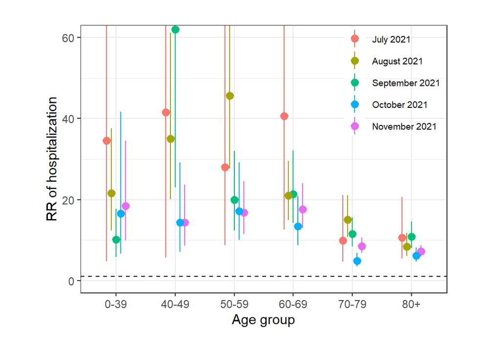

**Figure S3.** Relative risk of hospitalization for non-vaccinated individuals compared to vaccinated individuals stratified by age group and month.

## Comparing vaccine types

Because the vaccine type was missing in a large proportion of fully vaccinated hospitalized cases (Table 1), we could not directly estimate the $RR$ of hospitalization for non-fully vaccinated compared to fully vaccinated by vaccine type. However, restricting the analysis to fully vaccinated hospitalized cases with known vaccine type, we could assess the relative effectiveness between Moderna and Pfizer-BioNtech (see Methods section). This comes with the assumption that hospitalized cases are as likely to display which vaccine they received if they received Moderna or PfizerBioNtech. We did not consider Johnson-Johnson here give the low number of cases. We estimate that the $RR$ of hospitalization for fully vaccinated with Pfizer-BioNtech compared to fully vaccinated with Moderna was 1.8 (95%CI: 1.5 to 2.1). We also consider a stratification by age or by month (Figure S4).

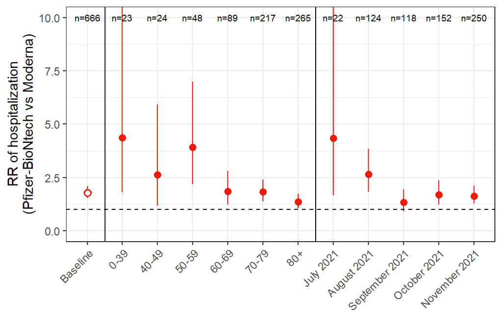

**Figure S4.** Relative change in the RR of hospitalization for individuals fully-vaccinated with Pfizer-BioNtech compared to individuals fully-vaccinated with Moderna, overall, by age group, and by month.